# Práctica limpieza y preprocesado de datos

Javier de Castro Rodríguez

2022-12-01

# 1. Objetivos

En esta práctica se pide **codificar** y **comentar** las acciones necesarias a realizar sobre un “messy dataset” para convetirlo en un “tidy dataset”, limpio y con un formato adecuado.

Se debe **explicar** las acciones con texto y codificarlas en R en un script R Markdown. En este se incluirá el código R con sus explicaciones pertinentes.

# 2. Carga y lectura de dataset

### Creación de directorio y carga de datos

Accedemos al directorio de trabajo, descargamos fichero desde la URL propuesta:

```r
currentDir <- getwd()
parentPath <- dirname(currentDir)
dir <- "Master"
file <- "EXAMPLE_DataToClean.xlsx"
fileURL <- "https://docs.google.com/spreadsheets/d/1CDWBeqpUTBd1TkmDz_M6UGRWdHgU7LOcoiGRTvIttKA/edit#gid=0"
library(downloader)
download.file(fileURL,"EXAMPLE_DataToClean", mode = "wb")
```

Cargamos librerias e instalamos paquetes en caso de no tenerlos ya instalados:

```r
libs <- c("tidyverse","readxl", "knitr", "xlsx", "xlsxjars", "rJava", "tidyr", "dplyr", "data.table") #lista de paquetes requeridos
```

```r
for (i in libs){
    print(i)
    if(!require(i, character.only = TRUE))  # require("package") devuelve TRUE o FALSE en función de si tenemos instalado o no el package
      { install.packages(i, dependencies=TRUE); library(i) }
}
```

```
## [1] "tidyverse"
```

```
## ───────────────────────────────────────
## tidyverse 1.3.2 ──
```

```
## [1] "readxl"
```

```
## [1] "knitr"
```

```
## [1] "xlsx"
```

```
## [1] "xlsxjars"
```

```
## [1] "rJava"
## [1] "tidyr"
## [1] "dplyr"
## [1] "data.table"
```

### Lectura los datos procedentes de un archivo Excel.

```r
parentPath <- dirname(currentDir)
EXAMPLE_DataToClean<- read.xlsx(paste0(parentPath, file = "/Master/EXAMPLE_DataToClean.xlsx"), 1, header=TRUE) # Sheet = 1 (carga hoja 1),
```

## 3. Limpieza de dataset

```r
colnames(EXAMPLE_DataToClean) # Obtenemos los nombres de las columnas.
```

```
## [1] "Year"
## [2] "Area..use.fill.down."
## [3] "Street..use.find.and.replace.to.replace.the.odd.character.with.a.space."
## [4] "Street.2..in.Refine.use.titlecase.and.cluster.and.edit."
## [5] "Strange.HTML..use.unescape.HTML."
```

```r
summary(EXAMPLE_DataToClean) # Podemos hacer una inspección preliminar con summary(). Obtenemos información sobre el nombre de las variables, tipo de objeto, dimensiones
```

```
##       Year      Area..use.fill.down.
##  Min.   :2011   Length:5279
##  1st Qu.:2011   Class :character
##  Median :2011   Mode  :character
##  Mean   :2011
##  3rd Qu.:2012
##  Max.   :2012
##  Street..use.find.and.replace.to.replace.the.odd.character.with.a.space.
##  Length:5279
##  Class :character
##  Mode  :character
##
##
##
##  Street.2..in.Refine.use.titlecase.and.cluster.and.edit.
##  Length:5279
##  Class :character
##  Mode  :character
##
##
##
##  Strange.HTML..use.unescape.HTML.
##  Length:5279
##  Class :character
##  Mode  :character
##
##
##
```

```r
#lapply (EXAMPLE_DataToClean, class) Podemos ver la clase de las columnas con función *lapply()*
```

```r
names(EXAMPLE_DataToClean) <- gsub(pattern = "[[:punct:]]", replacement = " ", names(EXAMPLE_DataToClean))# Para una mejor comprensión de los nombres quitamos los puntos y los reemplazamos por espacios con gsub()
```

Renombramos variables

```r
example_tidy <- rename(EXAMPLE_DataToClean, Area = (2), Street1 = (3), Street2 = (4), html = (5)) # rename() nos permite cambiar el nombre de las columnas que seleccionemos.
head(example_tidy)
```

```
##   Year       Area                Street1                Street2
## 1 2011 Birmingham           AcocksåGreen           Acocks Green
## 2 2011       <NA>         AdderlyåStreet         Adderly Street
## 3 2011       <NA>  AlcesteråRaod,åMosley  Alcester Raod, Mosley
## 4 2011       <NA>          alcesteråroad          alcester road
## 5 2011       <NA>  alcesteråroadåmoseley  alcester road moseley
## 6 2011       <NA>  AlcesteråRoadåMoseley  Alcester Road Moseley
##                         html
## 1              One &amp; Two
## 2         Some &ndash; ndash
## 3                  &euro;300
## 4         alcester&nbsp;road
## 5 &quot;That silly man&quot;
## 6               &lt;html&gt;
```

Se detectan **NA (not available)** valores en la columna **Area** :

```r
example_tidy <- example_tidy %>%  fill("Area", .direction = "down") # fill() nos permite reemplazar valores missing por valores previos. La dirección por default es down.
```

En la columna Street1 sustituimos caracter “å” por un espacio:

```r
example_tidy$Street1<- gsub("å"," ",example_tidy$Street1) # función gsub() para modificar las ocurrencias de una expresión por el segundo argumento, en nuestro caso un espacio

head(example_tidy)
```

```
##   Year       Area                Street1                Street2
## 1 2011 Birmingham           Acocks Green           Acocks Green
## 2 2011 Birmingham         Adderly Street         Adderly Street
## 3 2011 Birmingham  Alcester Raod, Mosley  Alcester Raod, Mosley
## 4 2011 Birmingham          alcester road          alcester road
## 5 2011 Birmingham  alcester road moseley  alcester road moseley
## 6 2011 Birmingham  Alcester Road Moseley  Alcester Road Moseley
##                         html
## 1              One &amp; Two
## 2         Some &ndash; ndash
## 3                  &euro;300
## 4         alcester&nbsp;road
## 5 &quot;That silly man&quot;
## 6               &lt;html&gt;
```

Para uniformizar la estructura de las columnas podemos poner la primera letra de cada palabra en mayúscula con *str_to_title()*. Si quisieramos poner todas las letras en mayúsculas o en minúsculas podríamos usar *toupper()* y *tolower()* respectivamente

```r
example_tidy$Street1 = str_to_title(example_tidy$Street1)
example_tidy$Street2 = str_to_title(example_tidy$Street2)
head(example_tidy)
```

```
##   Year       Area                Street1                Street2
## 1 2011 Birmingham           Acocks Green           Acocks Green
## 2 2011 Birmingham         Adderly Street         Adderly Street
## 3 2011 Birmingham  Alcester Raod, Mosley  Alcester Raod, Mosley
## 4 2011 Birmingham          Alcester Road          Alcester Road
## 5 2011 Birmingham  Alcester Road Moseley  Alcester Road Moseley
## 6 2011 Birmingham  Alcester Road Moseley  Alcester Road Moseley
##                         html
## 1              One &amp; Two
## 2         Some &ndash; ndash
## 3                  &euro;300
## 4         alcester&nbsp;road
## 5 &quot;That silly man&quot;
## 6               &lt;html&gt;
```

Vemos similitudes en filas de la columna Street1 y Street2. Podríamos simplificar en caso de tener valores duplicados

```r
#duplicated(example_tidy) determinamos cuales son los valores duplicados en filas

example_tidy1 <- example_tidy %>% distinct(Street1, Street2, html, Area, Year) # distinct() nos devueve los valores únicos de las columnas seleccionadas

head(example_tidy1)
```

```
##   Year       Area                Street1                Street2
## 1 2011 Birmingham           Acocks Green           Acocks Green
## 2 2011 Birmingham         Adderly Street         Adderly Street
## 3 2011 Birmingham  Alcester Raod, Mosley  Alcester Raod, Mosley
## 4 2011 Birmingham          Alcester Road          Alcester Road
## 5 2011 Birmingham  Alcester Road Moseley  Alcester Road Moseley
## 6 2011 Birmingham  Alcester Road Moseley  Alcester Road Moseley
##                         html
## 1              One &amp; Two
## 2         Some &ndash; ndash
## 3                  &euro;300
## 4         alcester&nbsp;road
## 5 &quot;That silly man&quot;
## 6               &lt;html&gt;
```

Comparamos columna Street1 con columna Street2

Comprobamos con *ifelse()* si Street1 y Street2 son iguales:

```r
example_tidy1$street <- ifelse(example_tidy1$Street1 != example_tidy1$Street2,
                                FALSE,
    ifelse(example_tidy1$Street1 == example_tidy1$Street2, TRUE))

head(example_tidy1)
```

```
##   Year       Area                Street1                Street2
## 1 2011 Birmingham           Acocks Green           Acocks Green
## 2 2011 Birmingham         Adderly Street         Adderly Street
## 3 2011 Birmingham  Alcester Raod, Mosley  Alcester Raod, Mosley
## 4 2011 Birmingham          Alcester Road          Alcester Road
## 5 2011 Birmingham  Alcester Road Moseley  Alcester Road Moseley
## 6 2011 Birmingham  Alcester Road Moseley  Alcester Road Moseley
##                         html street
## 1              One &amp; Two   TRUE
## 2         Some &ndash; ndash   TRUE
## 3                  &euro;300   TRUE
## 4         alcester&nbsp;road   TRUE
## 5 &quot;That silly man&quot;   TRUE
## 6               &lt;html&gt;   TRUE
```

Una vez comprobado que las columnas Street1 y Street2 son iguales eliminamos la columna Street2 y la variable que habíamos creado **street**

```r
example_tidy2 <- example_tidy1 %>% select(-c(Street2, street))
head(example_tidy2)
```

```
##   Year       Area                Street1                       html
## 1 2011 Birmingham           Acocks Green              One &amp; Two
## 2 2011 Birmingham         Adderly Street         Some &ndash; ndash
## 3 2011 Birmingham  Alcester Raod, Mosley                  &euro;300
## 4 2011 Birmingham          Alcester Road         alcester&nbsp;road
## 5 2011 Birmingham  Alcester Road Moseley &quot;That silly man&quot;
## 6 2011 Birmingham  Alcester Road Moseley               &lt;html&gt;
```

Sustituimos las ‘html entities’ *(‘ ’, ‘<’, ‘<’, ‘&’, ‘€’, ‘"’, … )* por su ‘Entity number’ (<, >, €, “, …)

```r
example_tidy2$html<- gsub("&amp;", " & ",example_tidy2$html)

example_tidy2$html<- gsub("&ndash;" , "-",example_tidy2$html)

example_tidy2$html<- gsub("&lt;" , "< ",example_tidy2$html)

example_tidy2$html<- gsub("&quot;" , " “ ",example_tidy2$html)

example_tidy2$html<- gsub("&euro;" , " € ",example_tidy2$html)

example_tidy2$html<- gsub("&nbsp;", " ",example_tidy2$html)

example_tidy2$html<- gsub("&gt;", " > ",example_tidy2$html)

example_tidy2$html<- gsub("&apos;", " ' ",example_tidy2$html)

example_tidy2$html<- gsub("ndash", " - ",example_tidy2$html)

head(example_tidy2)
```

```
##   Year       Area                Street1                 html
## 1 2011 Birmingham           Acocks Green          One  &  Two
## 2 2011 Birmingham         Adderly Street           Some -  -
## 3 2011 Birmingham  Alcester Raod, Mosley                € 300
## 4 2011 Birmingham          Alcester Road        alcester road
## 5 2011 Birmingham  Alcester Road Moseley  “ That silly man “
## 6 2011 Birmingham  Alcester Road Moseley            < html >
```

Una vez sustiuidos los caracteres especiales y ante la presencia de un número elevado de **NA**, podríamos prescindir de la columna **html** considerando que es de escasa relevancia

```r
example_tidy3 <- example_tidy2 %>% select(-c(html))
head(example_tidy3)
```

```
##   Year       Area                Street1
## 1 2011 Birmingham           Acocks Green
## 2 2011 Birmingham         Adderly Street
## 3 2011 Birmingham  Alcester Raod, Mosley
## 4 2011 Birmingham          Alcester Road
## 5 2011 Birmingham  Alcester Road Moseley
## 6 2011 Birmingham  Alcester Road Moseley
```

# 4. Visualización

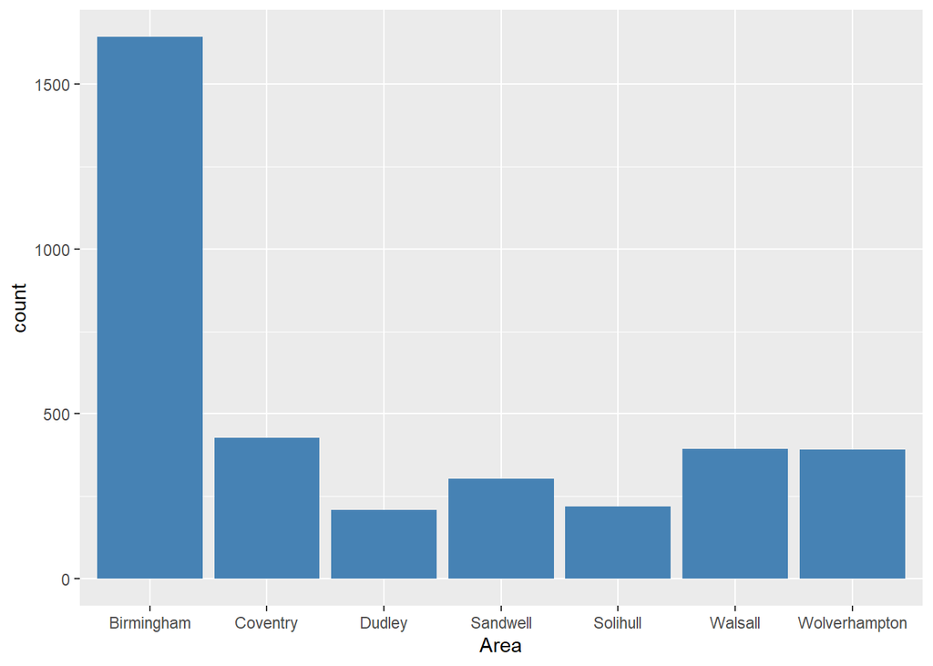

```r
ggplot(example_tidy3 , aes(Area), position (width = 1)) + geom_bar(fill = "steelblue")
```

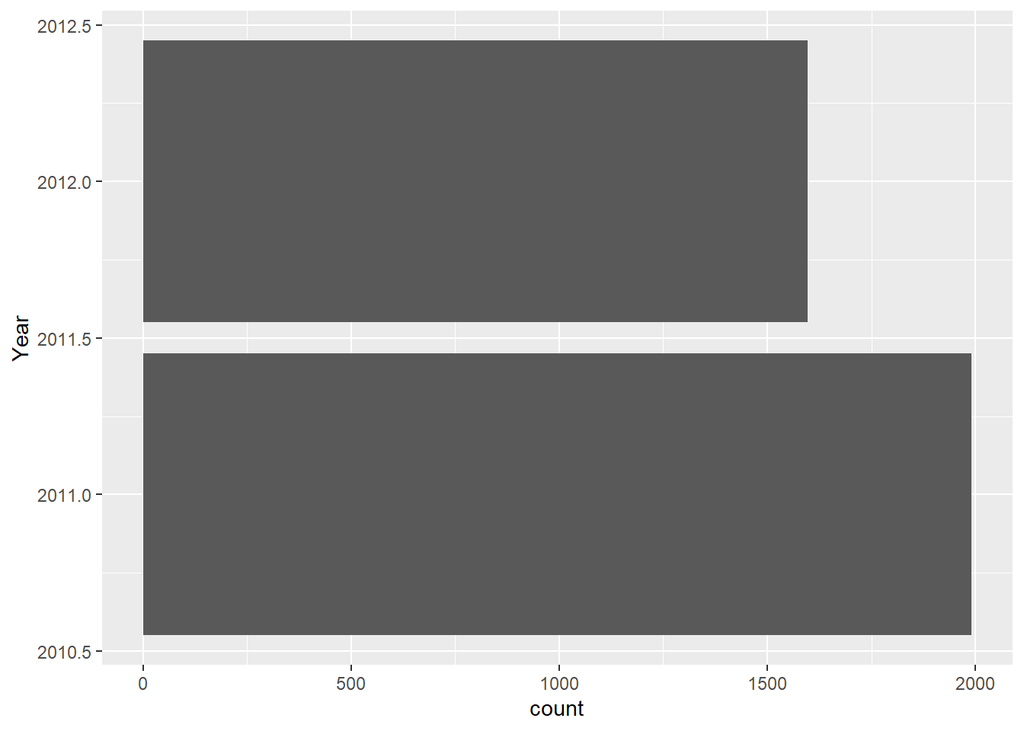

```r
ggplot(example_tidy3, aes(Year))+ geom_bar()+ coord_flip()
```

# 4. Exportar dataset

Exportamos a un fichero local el dataset trabajado

```r
library(rJava)

outputDir <- "../Master/datos/output"
if (!file.exists(outputDir)) {
  dir.create(outputDir)
}

write.xlsx(example_tidy3,  "./datos/exampletidy.xlsx")
```

# 5. Conclusiones

El mayor número de datos tomados es en al área de Birmingham durante el año 2011.

Mayor porcentaje de datos corresponde al año 2011.

Encontramos duplicidad de calles. El número de estas duplicidades es mayor en el área de Birmingham.

Falta un elevado número de registros en la columna “html”. No juega un papel relevante dentro del dataset.